# Yelp Dataset Review

Vidhyasree Ramu

March 15, 2017

# Loading required libraries

```r
library(jsonlite)
library(stringr)
library(readr)
library(dplyr)
library(tibble)
require(itertools)
```

# Function to read data from JSON File and convert it into dataframe

```r
createDF <- function(jsonFile){

  lines <- read_lines(jsonFile, n_max = 2000000, progress = FALSE)
  combined <- str_c("[", str_c(lines, collapse = ", "), "]")
  remove(lines)
  df <- fromJSON(combined) %>%flatten() %>%tbl_df()

  df
}
```

# Read the business and review json

```r
business.df <- createDF('/Users/deepak/Downloads/Vidhya/yelp_academic_dataset_business.json')

review.df <- createDF('/Users/deepak/Downloads/Vidhya/yelp_academic_dataset_review.json')
```

### Analysis:By categorizing the popular types of restaurants that are present in a state, we can identify new opportunities for prospective business owners to start new projects.

# For eg if the count of particular type of cusine is less in a particular state, it could be identified as potential opportunity to start that type of restaurant in that state or if people in particular area prefer only one type of cuisine then it better to start the business

# First, we filter the business data to get the Restaurant related information. The categories field provide this information but it is usually a list data type which contains all the variables that define the restaurant type like Fast food, burger, etc.,

```r
business_flat <- flatten(business.df)
business_table <- as_data_frame(business_flat)
```

# To understand what type of restaurant are more common in the dataset we need to unnest the categories list and assign a value to each row

```r
business_table %>% mutate(categories = as.character(categories)) %>% select(categories)
```

```
## # A tibble: 144,072 × 1
##                                                                     categories
##                                                                          <chr>
## 1                    c("Tobacco Shops", "Nightlife", "Vape Shops", "Shopping")
## 2  c("Caterers", "Grocery", "Food", "Event Planning & Services", "Party & Even
## 3                        c("Restaurants", "Pizza", "Chicken Wings", "Italian")
## 4  c("Hair Removal", "Beauty & Spas", "Blow Dry/Out Services", "Hair Stylists"
## 5                  c("Hotels & Travel", "Event Planning & Services", "Hotels")
## 6                                            c("Nail Salons", "Beauty & Spas")
## 7                                       c("Baby Gear & Furniture", "Shopping")
## 8                          c("Tex-Mex", "Mexican", "Fast Food", "Restaurants")
## 9                                          c("Local Services", "Self Storage")
## 10                                                       c("Food", "Bakeries")
## # ... with 144,062 more rows
```

```r
#Removing unneccessary variables
business_table %>%
  select(-starts_with("hours"), -starts_with("attribute"))
```

```
## # A tibble: 144,072 × 14
##               business_id                   name   neighborhood
## *                   <chr>                  <chr>          <chr>
## 1  0DI8Dt2PJp07XkVvIElIcQ      Innovative Vapors
## 2  LTlCaCGZE14GuaUXUGbamg          Cut and Taste
## 3  EDqCEAGXVGCH4FJXgqtjqg            Pizza Pizza Dufferin Grove
## 4  cnGIivYRLxpF7tBVR_JwWA    Plush Salon and Spa
## 5  cdk-qqJ71q6P7TJTww_DSA            Comfort Inn  Downtown Core
## 6  Q9rsaUiQ-A3NdEAloy0aJA            A Plus Nail
## 7  Cu4_Fheh7IrzGiK-Pc79ig         Boomerang Baby
## 8  GDnbt3isfhd57T1QqU6flg              Taco Bell
## 9  qwAHit4Tuj1zpO7CxVwOMA CubeSmart Self Storage
## 10 Nbr0kbtIrVlEcKIZoXWbSw        Sehne Backwaren
## # ... with 144,062 more rows, and 11 more variables: address <chr>,
## #   city <chr>, state <chr>, postal_code <chr>, latitude <dbl>,
## #   longitude <dbl>, stars <dbl>, review_count <int>, is_open <int>,
## #   categories <list>, type <chr>
```

```r
#counting number of restaurants
library(stringr)
business_table %>% select(-starts_with("hours"), -starts_with("attribute")) %>%
  filter(str_detect(categories, "Restaurant"))
```

```
## # A tibble: 48,493 × 14
##               business_id                      name   neighborhood
##                     <chr>                     <chr>          <chr>
## 1  EDqCEAGXVGCH4FJXgqtjqg               Pizza Pizza Dufferin Grove
## 2  GDnbt3isfhd57T1QqU6flg                 Taco Bell
## 3  42romV8altAeuZuP2OC1gw        Ohana Hawaiian BBQ
## 4  DNyYOxVAfu0oUcPNL1ljCQ               Chez Lionel
## 5  a1Ba6XeIOP48e64YFD0dMw                   La Prep    Ville-Marie
## 6  826djy6K_9Fp0ptqJ2_Yag    Chipotle Mexican Grill  Downtown Core
## 7  Mi5uhdFB9OJteXPd0_IKfw  Carrabba's Italian Grill
## 8  Uxh0fXFH_QQBivRnIBpdiw               Don Tequila
## 9  YPavuOh2XsnRbLfl0DH2lQ Lo-Lo's Chicken & Waffles
## 10 saWZO6hB4B8P-mIzS1--Xw              Kabob Palace  Spring Valley
## # ... with 48,483 more rows, and 11 more variables: address <chr>,
## #   city <chr>, state <chr>, postal_code <chr>, latitude <dbl>,
## #   longitude <dbl>, stars <dbl>, review_count <int>, is_open <int>,
## #   categories <list>, type <chr>
```

```r
# filtering only Business column and count
business_table %>% select(-starts_with("hours"), -starts_with("attribute")) %>%
  filter(str_detect(categories, "Restaurant")) %>%
  mutate(categories = as.character(categories)) %>% select(categories)
```

```
## # A tibble: 48,493 × 1
##                                                                     categories
##                                                                          <chr>
## 1                        c("Restaurants", "Pizza", "Chicken Wings", "Italian")
## 2                          c("Tex-Mex", "Mexican", "Fast Food", "Restaurants")
## 3                                     c("Hawaiian", "Restaurants", "Barbeque")
## 4                                                    c("Restaurants", "Cafes")
## 5                c("Sandwiches", "Breakfast & Brunch", "Salad", "Restaurants")
## 6                                     c("Fast Food", "Mexican", "Restaurants")
## 7                                       c("Restaurants", "Italian", "Seafood")
## 8                        c("Restaurants", "Mexican", "American (Traditional)")
## 9                         c("Restaurants", "Waffles", "Southern", "Soul Food")
## 10 c("Persian/Iranian", "Restaurants", "Ethnic Food", "Food", "Greek", "Specia
## # ... with 48,483 more rows
```

```r
library(tidyr)
business_table %>% select(-starts_with("hours"), -starts_with("attribute")) %>%
  filter(str_detect(categories, "Restaurant")) %>%
  unnest(categories) %>%
  select(name, categories)
```

```
## # A tibble: 179,136 × 2
##                  name    categories
##                 <chr>         <chr>
## 1         Pizza Pizza   Restaurants
## 2         Pizza Pizza         Pizza
## 3         Pizza Pizza Chicken Wings
## 4         Pizza Pizza       Italian
## 5           Taco Bell       Tex-Mex
## 6           Taco Bell       Mexican
## 7           Taco Bell     Fast Food
## 8           Taco Bell   Restaurants
## 9  Ohana Hawaiian BBQ      Hawaiian
## 10 Ohana Hawaiian BBQ   Restaurants
## # ... with 179,126 more rows
```

```r
# to get count of categories in the table
business_table %>% select(-starts_with("hours"), -starts_with("attribute")) %>%
  filter(str_detect(categories, "Restaurant")) %>%
  unnest(categories) %>%
  select(name, categories) %>%
  count(categories)
```

```
## # A tibble: 607 × 2
##             categories     n
##                  <chr> <int>
## 1           Acai Bowls    13
## 2          Accessories     3
## 3          Accountants     1
## 4          Active Life   177
## 5          Acupuncture     2
## 6                Adult     1
## 7      Adult Education     4
## 8  Adult Entertainment    18
## 9          Advertising     1
## 10              Afghan    80
## # ... with 597 more rows
```

# What are the most common restaurant types per state / province?

```r
# Getting top counts and getting rid of common tags like "Restautant" and "Food"

cat_table <- business_table %>% select(-starts_with("hours"), -starts_with("attribute")) %>%
  filter(str_detect(categories, "Restaurant")) %>%
  unnest(categories) %>%
  filter(categories != "Restaurants") %>%
  filter(categories != "Food") %>%
  count(state, categories) %>%
  arrange(desc(n))

library(DT)
datatable(cat_table, options = list(pageLength = 25))
```

|  | state | categories | n |
| --- | --- | --- | --- |
| 1 | AZ | Fast Food | 1556 |
| 2 | AZ | Mexican | 1462 |
| 3 | AZ | Sandwiches | 1408 |
| 4 | AZ | American (Traditional) | 1360 |
| 5 | AZ | Nightlife | 1281 |
| 6 | ON | Chinese | 1275 |
| 7 | ON | Nightlife | 1232 |
| 8 | AZ | Pizza | 1227 |
| 9 | AZ | Bars | 1220 |
| 10 | ON | Bars | 1181 |

[output cut: 3146 more lines]

# Analysis on whether lengthy reviews are useful

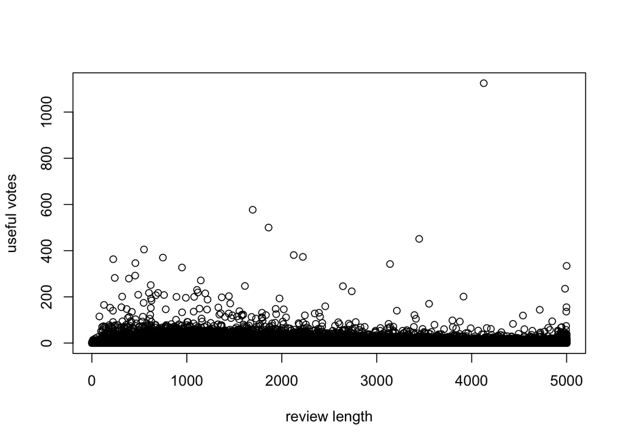

```r
master <- merge(business.df, review.df, by = "business_id")

master$review_length <- nchar(master$text)
x <- master$review_length
y<-master$useful
plot(x,y,xlab="review length",ylab="useful votes")
```